# 33.2. ロジスティック回帰分析（交差項）

Masahiko Asano

2025-08-21

Rを使った分析の準備

- ここで使うRのパッケージは次のとおり。

```r
library(corrplot)
library(jtools)
library(margins)
library(ROCR)
library(patchwork)
library(prediction)
library(stargazer)
library(tidyverse)
```

# 1. `Model_1` と `Model_2` の比較

- 交差項を含まないロジスティック回帰分析・・・・`Model_1`
- 交差項を含むロジスティック回帰分析・・・・`Model_2`
- それぞれのモデルで検証すべき仮説が異なる
- ここでは2つのモデルを比較しながら、交差項を含むロジスティック回帰分析で何が明らかになるかを解説する

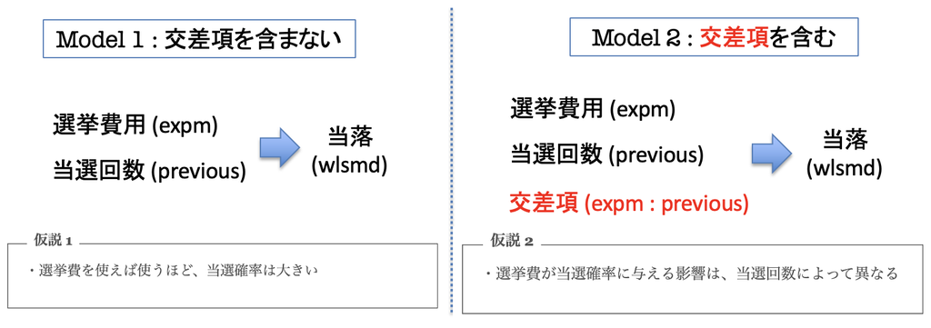

## 1.1 データの準備 (`hr96-24.csv`)

- ggplot2のテーマとフォントの設定を行う

```r
if (.Platform$OS.type == "windows") {
  if (require(fontregisterer)) {
    my_font <- "Yu Gothic"
  } else {
    my_font <- "Japan1"
  }
} else if (capabilities("aqua")) {
  my_font <- "HiraginoSans-W3"
} else {
  my_font <- "IPAexGothic"
}

theme_set(theme_gray(base_size = 9,
                     base_family = my_font))
```

- 衆議院議員総選挙の得票データ[`hr96-24.csv`](https://asanoucla.github.io/hr96-24.csv) をダウンロード

データのダウンロードが終わったら、データを読み込み `hr` と名前を付ける。

```r
hr <- read_csv("data/hr96-24.csv", na = ".")
```

データフレーム `hr` の中身を表示する

```r
names(hr)
```

```
 [1] "year"          "pref"          "ku"            "kun"
 [5] "wl"            "rank"          "nocand"        "seito"
 [9] "j_name"        "gender"        "name"          "previous"
[13] "age"           "exp"           "status"        "vote"
[17] "voteshare"     "eligible"      "turnout"       "seshu_dummy"
[21] "jiban_seshu"   "nojiban_seshu"
```

- `select()` 関数を使って `year`, `wl`, `previous`, `exp` という 4 つの変数だけを選ぶ
- `filter()` 関数を使って 2021年衆院選だけのデータを残す
- `wl` の中身を確認

```r
unique(hr$wl)
```

```
[1] 1 0 2
```

- 0・・・小選挙区での落選
- 1・・・小選挙区での当選
- 2・・・復活当選
- `wl` を使って、選挙結果を示す変数 `wlsmd` （1 = 小選挙区当選、0 = その他）を作る
- `exp` を使って、選挙費用を示す変数 `expm`（単位は「百万円」）を作る

```r
hr21 <- hr %>%
  select(year, wl, previous, exp) %>%
  filter(year == 2021) %>%
  mutate(wlsmd = ifelse(wl == 1, 1, 0)) |>
  mutate(expm = exp / 1000000) |>

  select(year, wlsmd, expm, previous)
```

データフレーム `hr21` の中身を表示する

```r
hr21
```

```
# A tibble: 857 × 4
    year wlsmd  expm previous
   <dbl> <dbl> <dbl>    <dbl>
 1  2021     1 13.4         3
 2  2021     0  9.62        2
 3  2021     0 NA           0
 4  2021     1  8.82        8
 5  2021     0 11.4         0
 6  2021     1  7.42        8
 7  2021     0 11.9         3
 8  2021     1 13.0         3
 9  2021     0  7.48        6
10  2021     0  4.61        0
# ℹ 847 more rows
```

**データ**：

| 変数名 | 詳細 |
| --- | --- |
| `year` | 衆院選が行われた年 |
| `wlsmd` | 小選挙区での当落ダミー(当選 = 1, 落選 = 0) |
| `previous` | 当選回数 |
| `expm` | 候補者の選挙費用（百万円） |

- データフレーム hr21 の記述統計を表示させる

```r
summary(hr21)
```

```
      year          wlsmd             expm              previous
 Min.   :2021   Min.   :0.0000   Min.   : 0.009319   Min.   : 0.000
 1st Qu.:2021   1st Qu.:0.0000   1st Qu.: 3.435080   1st Qu.: 0.000
 Median :2021   Median :0.0000   Median : 5.899882   Median : 1.000
 Mean   :2021   Mean   :0.3372   Mean   : 6.434585   Mean   : 2.162
 3rd Qu.:2021   3rd Qu.:1.0000   3rd Qu.: 8.692808   3rd Qu.: 3.000
 Max.   :2021   Max.   :1.0000   Max.   :27.443685   Max.   :17.000
                                 NA's   :22
```

- データフレーム `hr21` の `expm` に欠損値 (`missing data = NA's`) が22個あることがわかる
- `na.omit()` を使って欠測のない観測だけを残す

```r
hr21 <- na.omit(hr21)
```

- データフレーム `hr21` の記述統計を表示して確認する

```r
summary(hr21)
```

```
      year          wlsmd             expm              previous
 Min.   :2021   Min.   :0.0000   Min.   : 0.009319   Min.   : 0.000
 1st Qu.:2021   1st Qu.:0.0000   1st Qu.: 3.435080   1st Qu.: 0.000
 Median :2021   Median :0.0000   Median : 5.899882   Median : 1.000
 Mean   :2021   Mean   :0.3461   Mean   : 6.434585   Mean   : 2.211
 3rd Qu.:2021   3rd Qu.:1.0000   3rd Qu.: 8.692808   3rd Qu.: 3.000
 Max.   :2021   Max.   :1.0000   Max.   :27.443685   Max.   :17.000
```

- 22個の `NA's` が消えていることがわかる

## 1.2 `Model_1`: 交差項を含まないモデル

仮説 1・選挙費を使えば使うほど、当選確率は大きい

- この仮説を検証するために `Model_1` を推定する

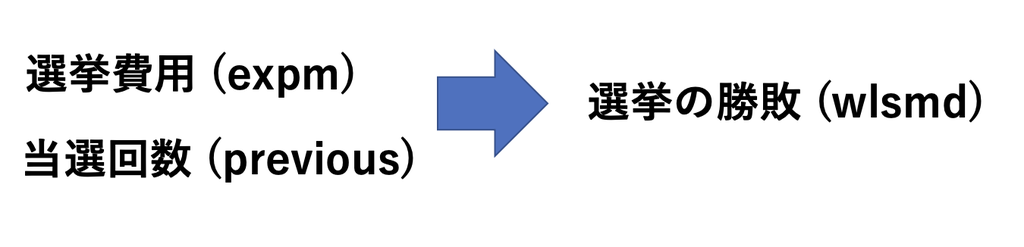

```r
stargazer::stargazer(as.data.frame(hr21),
  type = "html")
```

| Statistic | N | Mean | St. Dev. | Min | Max |
| --- | --- | --- | --- | --- | --- |
| year | 835 | 2,021.000 | 0.000 | 2,021 | 2,021 |
| wlsmd | 835 | 0.346 | 0.476 | 0 | 1 |
| expm | 835 | 6.435 | 4.287 | 0.009 | 27.444 |
| previous | 835 | 2.211 | 2.921 | 0 | 17 |

#### `Model 1` の分析結果

- ここでは2021年の衆院選データを用い、選挙費用（`expm`: 単位100万円）で衆院選小選挙区での当落 (`wlsmd`) を説明するモデルを推定する

```r
model_1 <- glm(wlsmd ~ expm + previous,
            data = hr21,
            family = binomial(link = "logit")) # 係数を「オッズの対数」に指定
```

- この結果を stargazerパッケージを使ってまとめてみる

```r
stargazer::stargazer(model_1,
  type = "html")
```

|  | *Dependent variable:* |
| --- | --- |
|  | wlsmd |
| expm | 0.170*** |
|  | (0.024) |
| previous | 0.342*** |
|  | (0.036) |
| Constant | -2.652*** |
|  | (0.194) |
| Observations | 835 |
| Log Likelihood | -397.969 |
| Akaike Inf. Crit. | 801.939 |
| *Note:* | p<0.1; p<0.05; p<0.01 |

→ 表示される回帰式の係数 `estimate` は「オッズの対数」: `log(odds)`  
= `log-odds` = `logit` と呼ばれる

- ロジスティック回帰分析の係数 `log-odds`は、重回帰分析の係数と同じように解釈できない

##### `log-odds` は解釈しにくい → オッズ比や確率に変換する

### `Model_1` の結果

```r
hr21_pred <- cplot(model_1,
                  x = "expm",
                  what = "prediction") %>% # Y軸に予測当選確率を表示させる設定
  as_data_frame() %>%
  ggplot(aes(x = xvals,
    y = yvals,
    ymin = lower,
    ymax = upper)) +
  geom_ribbon(fill = "gray") +
  geom_line() +
labs(x = "選挙費用（単位：100万円）",
     y = "予測当選確率の予測値（確率: 0 〜 1）",
     title = "予測当選確率の予測値:2021総選挙")
```

```r
hr21_me <- cplot(model_1,
                  x = "expm",    # x軸に据える変数
                  dx = "expm",   # 説明変数
                  what = "effect") %>%　# Y軸に限界効果を表示させる設定
  as_data_frame() %>%
  ggplot(aes(x = xvals,
    y = yvals,
    ymin = lower,
    ymax = upper)) +
  geom_ribbon(fill = "gray") +
  geom_line() +
  geom_abline(intercept = 0, slope = 0, linetype = "dashed", color = "red") +
  ylim(-0.0001, 0.06) +
labs(x = "選挙費用（単位：100万円）",
     y = "選挙費用の限界効果（確率: 0 〜 1）",
     title = "選挙費用の限界効果:2021総選挙")
```

**仮説検証のまとめ（仮説 1）:**

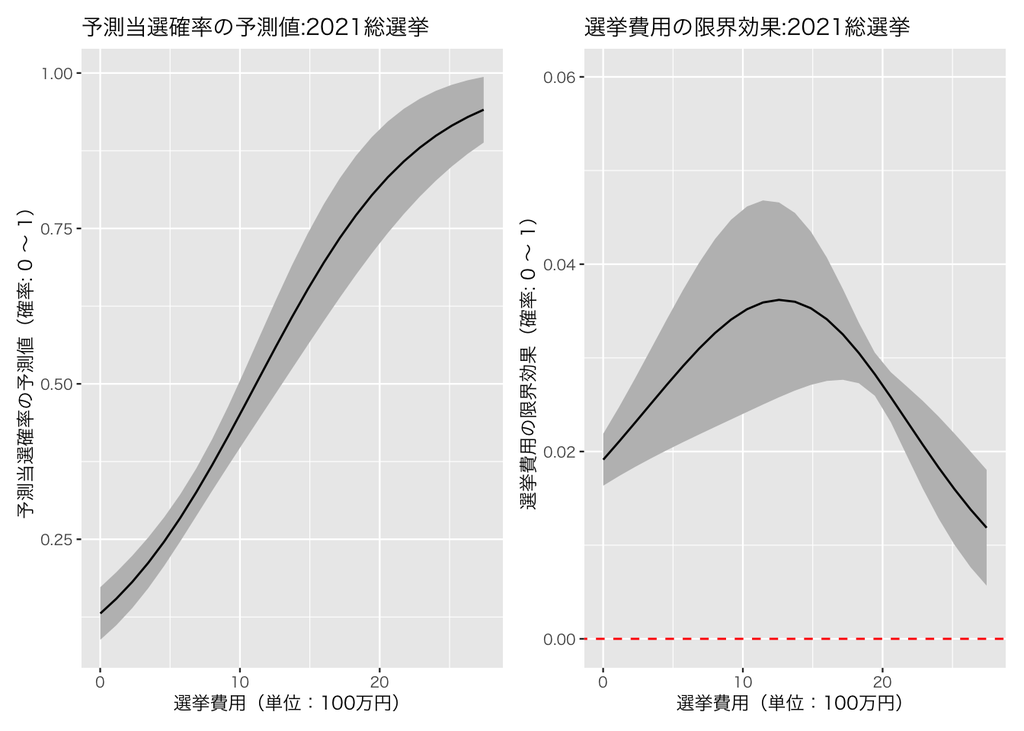

```r
hr21_pred + hr21_me
```

仮説検証の結論（仮説 1）:`当選回数が平均値 (2.211回)の候補者の場合`

## 1.3 `Model_2`: 交差項を含むモデル

仮説 2・選挙費が当選に与える影響は、当選回数によって異なる

- この仮説を検証するために `Model_2` を推定する

**Model 2**

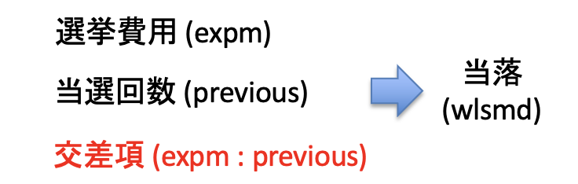

#### `Model 2` の分析結果

```r
model_2 <- glm(wlsmd ~ expm*previous,
            data = hr21,
            family = binomial(link = "logit")) # 係数を「オッズの対数」に指定
```

- この結果を stargazerパッケージを使ってまとめてみる
- `model_1` と `model_2` の結果を並べて表示させてみる

```r
stargazer::stargazer(model_1, model_2,
  type = "html")
```

|  | *Dependent variable:* |  |
| --- | --- | --- |
|  | wlsmd |  |
|  | (1) | (2) |
| expm | 0.170*** | 0.282*** |
|  | (0.024) | (0.033) |
| previous | 0.342*** | 0.689*** |
|  | (0.036) | (0.075) |
| expm:previous |  | -0.044*** |
|  |  | (0.008) |
| Constant | -2.652*** | -3.404*** |
|  | (0.194) | (0.263) |
| Observations | 835 | 835 |
| Log Likelihood | -397.969 | -382.279 |
| Akaike Inf. Crit. | 801.939 | 772.557 |
| *Note:* | p<0.1; p<0.05; p<0.01 |  |

- カッコの中は標準誤差 (`standard error`) を表す
- 表示される回帰式の係数 `estimate` は「オッズの対数」: `log(odds)`  
  = `log-odds` = `logit` と呼ばれる  
  → 重回帰分析の係数と同じように解釈できない
- `model_2` の結果（図の右側）が意味しているのは  
  ⇒ **調整変数が 0 の時 (`previous = 0)`の結果**
- つまり、`previous = 0`の候補者が100万円使うと当選確率に正の影響 (0.282) がある

#### 結果のまとめ（図の右側の結果）

- いずれの結果も統計的に有意

| expmの係数 (0.282): | expm が増えると当選確率は増加する |
| --- | --- |
| previous の係数 (0.689): | previous が多いほど当選確率は増加する |
| expm:previousの係数 (-0.044): | **previous が大きくなると expm の効果は弱まる** |

- しかし、数値は「オッズの対数」なので、確率 (%) に変換して可視化する必要がある

#### `margins::cplot` を使って「予測当選確率」と「限界効果」を可視化する

#### 「選挙費用」と「予測当選確率」(`hr21_pred`)

- 注意：チャンクオプションに````{r, echo = TRUE, fig.show = "hide"}`と指定する

```r
hr21_pred <- margins::cplot(model_2,
                  x = "expm",
                  what = "prediction") %>% # Y軸に予測当選確率を表示させる設定
  as_data_frame() %>%
  ggplot(aes(x = xvals,
    y = yvals,
    ymin = lower,
    ymax = upper)) +
  geom_ribbon(fill = "gray") +
  geom_line() +
labs(x = "選挙費用（単位：100万円）",
     y = "予測当選確率の予測値",
     title = "予測当選確率の予測値:2021総選挙")
```

- `expm` が増えると当選確率は増加している

#### 「選挙費用」と「選挙費用の限界効果」(`hr21_me`)

- 注意：チャンクオプションに````{r, echo = TRUE, fig.show = "hide"}`と指定する

```r
hr21_me <- margins::cplot(model_2,
                  x = "previous",    # x軸に据える変数
                  dx = "expm",   # 説明変数
                  what = "effect") %>%　# Y軸に限界効果を表示させる設定
  as_data_frame() %>%
  ggplot(aes(x = xvals,
    y = yvals,
    ymin = lower,
    ymax = upper)) +
  geom_ribbon(fill = "gray") +
  geom_line() +
  geom_abline(intercept = 0, slope = 0, linetype = "dashed", color = "red") +
  ylim(-0.05, 0.05) +
labs(x = "当選回数",
     y = "選挙費用の限界効果（当選回数ごと）",
     title = "選挙費用の限界効果:2021総選挙")
```

**仮説検証のまとめ（仮説 2）:**

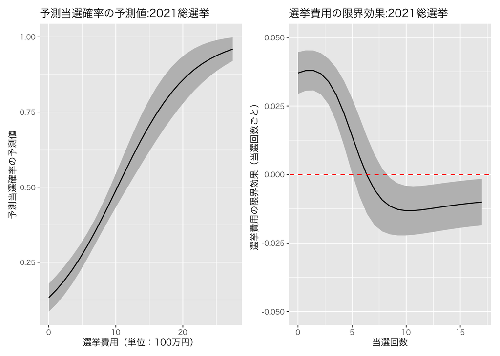

```r
hr21_pred + hr21_me
```

仮説検証の結論（仮説 2）

##### 左側の図からわかること

**・選挙費用が大きくなるにつれて、候補者の当選確率は大きくなる**  
・選挙費用が小さいとき、予測当選確率は緩やかに上昇  
・選挙費用が中程度になると曲線の傾きが少しずつ急になる  
・選挙費用が大きくなると再び傾きが小さくなる

##### 右側の図からわかること

**・選挙費用の限界効果は、当選回数が増える程小さくなる**  
・当選回数が5回程度まではこの傾向が続き、統計的にも有意  
・当選回数が6回〜8回あたりまでは統計的に有意ではない  
・当選回数が9回以降は選挙費用が当選回数に負の影響を与える

#### 選挙費用が予測当選確率に与える「影響」を当選回数別に可視化する

- 綺麗に可視化するためには、`expm` と `previous` の記述統計をチェックする必要がある

```r
stargazer::stargazer(as.data.frame(hr21),
  type = "html")
```

| Statistic | N | Mean | St. Dev. | Min | Max |
| --- | --- | --- | --- | --- | --- |
| year | 835 | 2,021.000 | 0.000 | 2,021 | 2,021 |
| wlsmd | 835 | 0.346 | 0.476 | 0 | 1 |
| expm | 835 | 6.435 | 4.287 | 0.009 | 27.444 |
| previous | 835 | 2.211 | 2.921 | 0 | 17 |

- 下のスクリプトで当選回数 (`preious`) と選挙費用 (`expm`) を適切な大きさに分割する際、上の記述統計が参考になる

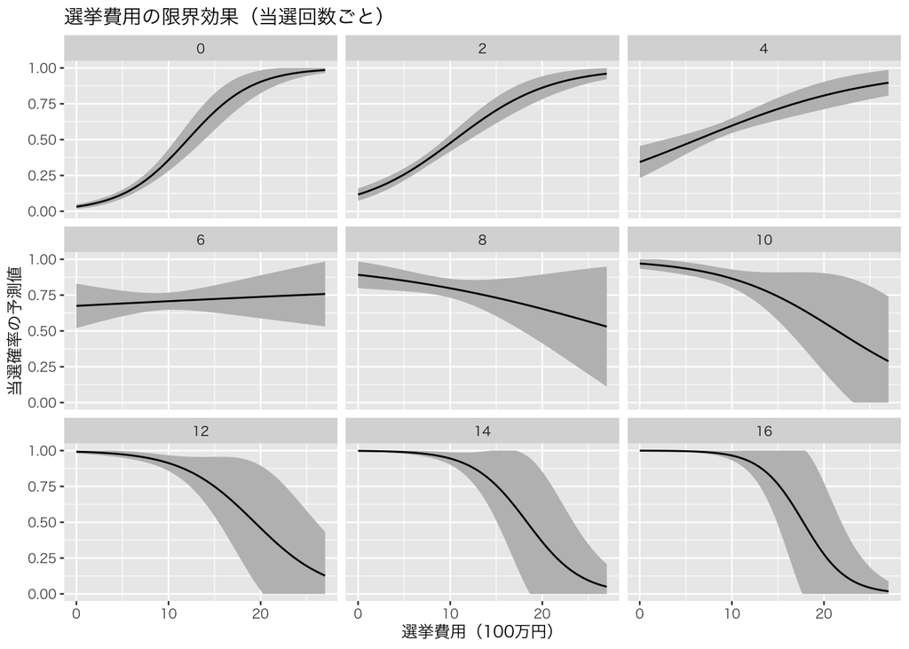

```r
df_pre <- expand.grid(previous = seq(0, 17, by = 2), # 当選回数を0から17回まで2回ずつ離して指定
  expm = seq(0, 27, by = 0.1)) |> # 選挙費用を0から1700万円まで200万円ずつ離して指定
  as_data_frame()
pred <- predict(model_2,
  type = "response",
  newdata = df_pre,
  se.fit = TRUE)
df_pre$fit <- pred$fit
df_pre$lower <- with(pred, fit - 2 * se.fit)
df_pre$upper <- with(pred, fit + 2 * se.fit)
df_pre <- df_pre %>%

mutate(lower = ifelse(lower < 0, 0, lower),
  upper = ifelse(upper > 1, 1, upper))
plt_prob <- ggplot(df_pre, aes(x = expm, y = fit)) +
  geom_ribbon(aes(ymin = lower, ymax = upper), fill = "gray") +
geom_line() +
facet_wrap(. ~ previous) +
  labs(x = "選挙費用（100万円）", y = "当選確率の予測値") +
ggtitle("選挙費用の限界効果（当選回数ごと）")

print(plt_prob)
```

この図からわかること・当選回数が 0 回の候補者は、選挙費用が増えると当選確率高くなっている  
・当選回数が 6 回の候補者はお金を使っても使わなくてもほとんど当選確率に変化はなく、高い当選確率を維持している  
・当選回数が 8 回を超える候補者だと、選挙費用はむしろマイナスの影響すら与えるようになることが読み取れる

## 1.4 モデルの当てはまり具合を評価する

```r
model_1 <- glm(wlsmd ~ expm + previous,
            data = hr21,
            family = binomial(link = "logit")) # 係数を「オッズの対数」に指定

model_2 <- glm(wlsmd ~ expm*previous,
            data = hr21,
            family = binomial(link = "logit")) # 係数を「オッズの対数」に指定
```

### ROC曲線によるモデルの当てはまり具合の評価方法

- 交差項を含まない `model_1` と交差項を含む `model_2` のどちらの当てはまりがよいかを、`ROC曲線`を描いて考える
- `ROC曲線`を描くために **ROCR パッケージ**を使う
- `prediction()` という名前の関数は **ROCR** パッケージだけでなく **margins** パッケージにもある  
  →どちらの関数を使うか明記する

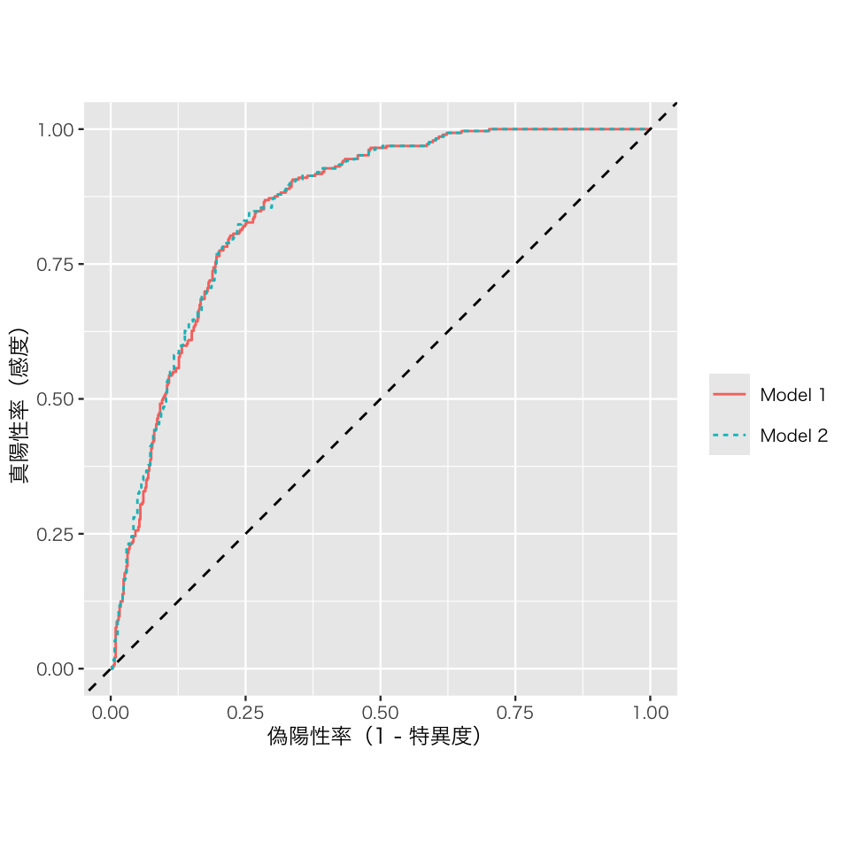

```r
pi1 <- predict(model_1, type = "response")
pi2 <- predict(model_2, type = "response")
pr1 <- ROCR::prediction(pi1, labels = hr21$wlsmd == "1")
pr2 <- ROCR::prediction(pi2, labels = hr21$wlsmd == "1")
roc1 <- performance(pr1, measure = "tpr", x.measure = "fpr")
roc2 <- performance(pr2, measure = "tpr", x.measure = "fpr")
df_roc <- data_frame(fpr = c(roc1@x.values[[1]], roc2@x.values[[1]]),
                     tpr = c(roc1@y.values[[1]], roc2@y.values[[1]])) %>%
  mutate(model = rep(c("Model 1", "Model 2"), c(n()/2, n()/2)))
roc <- ggplot(df_roc, aes(x = fpr, y = tpr,
                          color = model, linetype = model)) +
  geom_line() +
geom_abline(intercept = 0, slope = 1, linetype = "dashed") +
  scale_linetype_discrete(name = "") +
  scale_color_discrete(name = "") +
  coord_fixed() +
  labs(x = "偽陽性率（1 - 特異度）", y = "真陽性率（感度）")
print(roc)
```

`ROC`曲線による当てはまり オレンジ色 (model_1) も青色 (model_2) の`ROC` 曲線もどちらも同じくらい 45 度線（点線）から点(0, 1) のほうに離れており、モデルの当てはまりが同じくらい良い

### 数値指標によるモデルの当てはまり具合の評価方法

#### AUC

- 目視だけで当てはまり具合の良し悪しを判断するのには限界がある  
  → AUC（**area under the curve**：ROC 曲線の下側の面積）を使って評価する
- 上のROCを求めた図中の 0 ≤x ≤1、0 ≤y ≤1 の範囲で ROC 曲線より下の面積を求める
- すべての ROC 曲線が2 点(0, 0) と(1, 1) を通り、当てはまりのよいモデル ほど(1, 1) の近くを通る
- ROC 曲線が 3 点(0, 0)、(0, 1)、(1, 1) を通るなら →曲線の下側の面積は 1
- **当てはまりのよいモデルの AUC** → 1 に近くなる
- **当てはまりの悪いモデルの AUC** → 0.5 に近くなる  
  （←ROC 曲線は 45 度線に近づくため）
- ROC曲線で見る限り、二つのモデルの当てはまりのよさに大きな差はなさそう
- 念のため、`AUC`を計算する

```r
auc1 <- performance(pr1, measure = "auc")
auc1@y.values[[1]]   # model_1 のAUC
```

```
[1] 0.853502
```

```r
auc2 <- performance(pr2, measure = "auc")
auc2@y.values[[1]]   # model_2 のAUC
```

```
[1] 0.8552955
```

`AUC` による当てはまり ・`AUC`を見る限り、ほんのわずかだけ`model_2` の当てはまりの方がよい  
・ほとんど変わらない

#### 赤池情報量基準 (`AID`)

- 赤池情報量基準 (`AID: Akaike information criterion`) を使う
- 多くの説明変数を使っても(= パラメータ数が増えても)、それに応じた分だけ尤度が増加しなければ、そのモデルは「良いモデル」とは言えない
- この基準で評価するのが `AID`
- `AIC` が最小のモデルが「最も良いモデル」とされる

```r
AIC(model_1)
```

```
[1] 801.9386
```

```r
AIC(model_2)
```

```
[1] 772.5572
```

`AID` による当てはまり `model_2` の当てはまりの方がよい

# 2. Excercise

- **2021年総選挙データ**を使って、立候補者が小選挙区で当選したか否か（`wlsmd`）を応答変数、過去の当選回数（`previous`）と選挙費用（`expm`）を説明変数としたロジスティック回帰分析を実行し、以下の各問に答えなさい。
- 分析で使うデータは衆院選選挙データは hr96-24.csv からダウンロード。

`Q1.`当選予測確率を縦軸に、選挙費用（`expm`）を横軸にとった散布図（`wlsmd`のオッズをとった曲線）を描きなさい。

`Q2.`立候補者が小選挙区で当選したか否か（`wlsmd`）を応答変数、選挙費用（`expm`）を説明変数としたモデルに `model_1` という名前を付けてロジスティック回帰分析し、`stargazer()`関数を使ってその結果を表示しなさい。

`Q3.`立候補者が小選挙区で当選したか否か（`wlsmd`）を応答変数、選挙費用（`expm`）を説明変数、そして過去の当選回数（`previous`）を調整変数として `expm:previous` という交差項をモデルに加え `model_2` という名前を付けてロジスティック回帰分析し、`stargazer()`関数を使って `model_1` と `model_2` の結果を並べて表示させなさい。

`Q4.` `model_2` の分析結果の `expm` と `previous` の係数が何を意味しているのかを説明し、この結果からわかることを述べなさい。

`Q5.` `margins::cplot()`関数を使って `model_2` の推定結果を表示し結論を述べなさい。分析結果は `patchwork`パッケージを使って表示させること。

`Q6.` `model_1` と `model_2` それぞれの ROC 曲線を比較して示し、どちらがよりよいモデルかこたえなさい。

`Q7.` `model_2` において、当選回数ごとの予測当選確率とその統計的有意性を `margins::cplot()` 関数を使って推定しなさい。

`Q8.` 選挙費用が予測当選確率に与える「影響」を当選回数別に可視化して示し、その傾向を簡単に説明しなさい。

`Q9.` `model_1` と `model_2` それぞれの ROC 曲線を比較して示し、どちらがよりよいモデルかこたえなさい。

`Q10.` `model_1` と `model_2` それぞれの 数値指標によるモデルの当てはまり具合の評価方法 (AUC と AID) を比較して示し、どちらがよりよいモデルかこたえなさい。

**参考文献**

- Kieran Healy, DATA VISUALIZATION, Princeton, 2019
- [宋財泫 (Jaehyun Song)・矢内勇生 (Yuki Yanai)「私たちのR: ベストプラクティスの探究」](https://www.jaysong.net/RBook/)
- 浅野正彦, 矢内勇生.『Rによる計量政治学』オーム社、2018年
- 浅野正彦, 中村公亮.『初めてのRStudio』オーム社、2018年
- Winston Chang, R Graphics Cookbook, O’Reilly Media, 2012.
- Kosuke Imai, Quantitative Social Science: An Introduction, Princeton University Press, 2017